# A handy guide to using the ToMATo algorithm

### Example 6

In this last example, closer to the kind of datasets we could find in real life, we will work with the famous "Digits dataset", containing 1797 observations each with 64 features: each entry represents a (highly compressed) hand-written digit in a 8x8 grid, where each cell can vary from 0 to 16, representing its opacity. Naturally, the dataset also contains the correct labels of each instance: a number from 0 to 9, the one written in the grid.

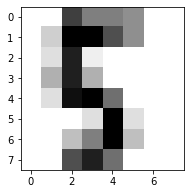

```python
#Load the digits dataset
digits = datasets.load_digits()

#Display the 25th digit
plt.figure(1, figsize=(3, 3))
plt.imshow(digits.images[25], cmap=plt.cm.gray_r, interpolation='nearest')
plt.show()
```

It is well known the difficulty of performing data science algorithms in high dimension, and clustering is not an exception; in fact, it is a process particularly sensitive to numerical data being sparse. Thus, even with dimensionality reduction techniques, it's not a good idea to expect a brilliant performance of our algorithm in this setting. In any case, it is interesting to see what kind of results we get. The results of other clustering methods over this dataset can be found in [4].

```python
digits, real_label = datasets.load_digits(return_X_y=True)

print(digits)
print(real_label)
```

```
[[ 0.  0.  5. ...  0.  0.  0.]
 [ 0.  0.  0. ... 10.  0.  0.]
 [ 0.  0.  0. ... 16.  9.  0.]
 ...
 [ 0.  0.  1. ...  6.  0.  0.]
 [ 0.  0.  2. ... 12.  0.  0.]
 [ 0.  0. 10. ... 12.  1.  0.]]
[0 1 2 ... 8 9 8]
```

We can embed the dataset in the plane by using PCA dimensionality reduction. We observe that, with that reduction level, the different clusters of numbers are somewhat distinguishable, but there is also considerable overlapping:

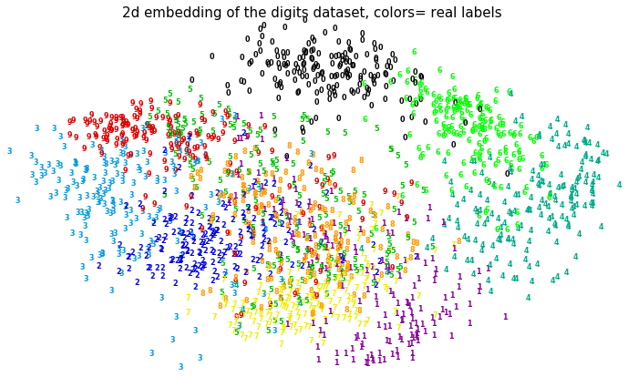

```python
from sklearn.decomposition import PCA

pca = PCA(n_components=2)
digits_red = pca.fit_transform(digits)

def plot_clustering(X_red, labels, title=None):
    x_min, x_max = np.min(X_red, axis=0), np.max(X_red, axis=0)
    X_red = (X_red - x_min) / (x_max - x_min)

    plt.figure(figsize=(6, 4))
    for i in range(X_red.shape[0]):
        plt.text(X_red[i, 0], X_red[i, 1], str(y[i]),
                 color=plt.cm.nipy_spectral(labels[i] / 10.),
                 fontdict={'weight': 'bold', 'size': 8})

    plt.xticks([])
    plt.yticks([])
    if title is not None:
        plt.title(title, size=15)
    plt.axis('off')
    fig = plt.gcf()
    fig.set_size_inches(12,7)

plot_clustering(digits_red, real_label, title = "2d embedding of the digits dataset, colors= real labels")
```

It's useless to try to run the algorithm without doing any kind of dimensionality reduction first: accurate density estimation is almost always unsucessful with highly sparse data. We can try to use our algorithm after killing some dimensions first. Wit our dataset, after some experimentation, when there are 11 dimensions left DTM density estimation looks quite well:

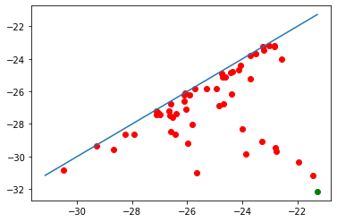

```python
pca = PCA(n_components=11)
digits_red = pca.fit_transform(digits)

ex6 = Tomato(
        input_type="points",
        metric="euclidean",
        graph_type="knn",
        density_type="logDTM",
        n_clusters=10,
        k=9,
    )

ex6.fit(digits_red)
ex6.plot_diagram()
```

It looks like the algorithm found "naturally" 9-10 clusters, let's plot these 10 groups in 2D:

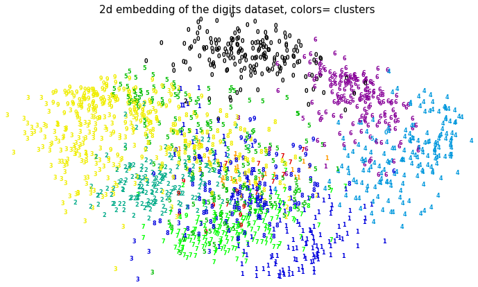

```python
labels = ex6.fit_predict(digits_red)

pca = PCA(n_components=2)
digits_red = pca.fit_transform(digits_red)

plot_clustering(digits_red, labels, title = "2d embedding of the digits dataset, colors= clusters")
```

The result looks suprisingly good, actually.

A way to measure the matching degree consists in computing the vector $10 \cdot \text{real_labels} + \text{clustering_labels}$, which takes values $\in \{0, \dots, 99\}$, and then counting the number of times each number appears. In a perfect classification, only 10 values would appear, more specifically $10\cdot i + label_{i}$, with $i \in \{0, \dots, 10\}$; in a decent clustering, we should at least see some clearly more prominent values, which is indeed what happens in our case!

```
[ 0 12 27 ... 82 97 87]
```

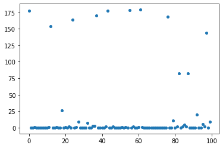

```python
vect_count = 10*real_label + labels
print(vect_count)

count = np.zeros((2,100))
for i in range(100):
    count[0,i]= i
for i in vect_count:
    count[1,i] += 1

fig, ax = plt.subplots();
ax.cla()
ax.scatter(count[0,:], count[1,:], s=16);
```

From this graph it looks like most of the values have been properly grouped. Only the value 8 looks more mismatched. We can also get an idea about how the numbers have been grouped or labeled using a table, and checking the columns and rows: each of them should only contain one "big" value:

```python
import pandas as pd
data = [[1, 2], [3, 4]]
pd.DataFrame(data, columns=["Foo", "Bar"])

table = []
for i in range(10):
    row = []
    #row.append(i)
    for i in range(i*10, i*10 +10):
        row.append(count[1, i])
    table.append(row)

pd.DataFrame(table, columns=[ 'Label 0', 'Label 1', 'Label 2', 'Label 3', 'Label 4', 'Label 5', 'Label 6', 'Label 7', 'Label 8', 'Label 9'])
```

|  | Label 0 | Label 1 | Label 2 | Label 3 | Label 4 | Label 5 | Label 6 | Label 7 | Label 8 | Label 9 |
| --- | --- | --- | --- | --- | --- | --- | --- | --- | --- | --- |
| 0 | 177.0 | 0.0 | 0.0 | 1.0 | 0.0 | 0.0 | 0.0 | 0.0 | 0.0 | 0.0 |
| 1 | 0.0 | 1.0 | 154.0 | 0.0 | 0.0 | 1.0 | 0.0 | 0.0 | 26.0 | 0.0 |
| 2 | 1.0 | 0.0 | 2.0 | 0.0 | 164.0 | 0.0 | 1.0 | 9.0 | 0.0 | 0.0 |
| 3 | 0.0 | 0.0 | 7.0 | 0.0 | 0.0 | 3.0 | 3.0 | 170.0 | 0.0 | 0.0 |
| 4 | 0.0 | 0.0 | 2.0 | 177.0 | 0.0 | 0.0 | 2.0 | 0.0 | 0.0 | 0.0 |
| 5 | 0.0 | 1.0 | 0.0 | 1.0 | 0.0 | 178.0 | 0.0 | 2.0 | 0.0 | 0.0 |
| 6 | 1.0 | 179.0 | 1.0 | 0.0 | 0.0 | 0.0 | 0.0 | 0.0 | 0.0 | 0.0 |
| 7 | 0.0 | 0.0 | 0.0 | 0.0 | 0.0 | 0.0 | 168.0 | 0.0 | 0.0 | 11.0 |
| 8 | 0.0 | 2.0 | 82.0 | 0.0 | 2.0 | 4.0 | 2.0 | 82.0 | 0.0 | 0.0 |
| 9 | 0.0 | 0.0 | 20.0 | 0.0 | 0.0 | 5.0 | 2.0 | 144.0 | 0.0 | 9.0 |

The clustering has been quite successful. In any case, the numbers 3's and 9's have been almost completely clustered together (which is not that suprising, given the low resolution of the dataset), and the number 8 is almost evenly divided between labels 2 (with the 1's) and 7 (with the 3's and 9's), again not very surprising.

### References

[1]. Frédéric CHAZAL et al., *Persistence-Based Clustering in Riemannian Manifolds* . In :Journal of the ACM 60 (juin 2011).doi:10.1145/1998196.1998212 : URL: https://hal.inria.fr/inria-00389390/document

[2]. Tutorial for DTM: https://github.com/GUDHI/TDA-tutorial/blob/master/Tuto-GUDHI-DTM-filtrations.ipynb

[3]. Gérard BIAU, Frédéric CHAZAL, David COHEN-STEINER, Luc DEVROYE, Carlos RODRIGUEZ. *A Weighted k-Nearest Neighbor Density Estimate for Geometric Inference* . 2011. ffinria-00560623v1 : URL: http://luc.devroye.org/BiauChazalCohenDevroyeRodriguez-kNN-2EJS-2011.pdf

[4] Various Agglomerative Clustering on a 2D embedding of digits: https://scikit-learn.org/stable/auto_examples/cluster/plot_digits_linkage.html#sphx-glr-auto-examples-cluster-plot-digits-linkage-py